# BI303 - Lab1 - Forest Succession

Zoey Werbin

1/22/2021

```r
library(dplyr)
```

```r
library(tidyr)
library(ggplot2)
```

## 1. Enter data

To match the steps of the lab handout, we will create two tables: one for each site. In R, these are called *data frames*, and they are used when we have multiple types of data (such as site categories, and numeric values). To create the data frames, we will use the `cbind()` function, which binds columns together. The table we create is saved to an object using the `<-` operator. We then use the `print()` function to view what we have created.

```r
site1 <- cbind.data.frame(site = "site1",
                                                    plot = c("plot1", "plot2","plot3"),
                                                    plot_area = c(20, 20, 20),
                                                    Pinus_strobus = c(13, 17, 11),
                                                    Betula_papyrifera = c(16, 19, 23),
                                                    Fagus_grandifolia = c(2, 0, 5))
print(site1)
```

```
##    site  plot plot_area Pinus_strobus Betula_papyrifera Fagus_grandifolia
## 1 site1 plot1        20            13                16                 2
## 2 site1 plot2        20            17                19                 0
## 3 site1 plot3        20            11                23                 5
```

We do the same for site 2, then combine the data frames from each site:

```r
site2 <- cbind.data.frame(site = "site2",
                                                    plot = c("plot1", "plot2","plot3"),
                                                    plot_area = c(30, 30, 30),
                                                    Pinus_strobus = c(10, 12, 9),
                                                    Betula_papyrifera = c(8, 1, 3),
                                                    Fagus_grandifolia = c(12, 10, 22))

# Combine data from both sites into one data frame using row-bind (`rbind.data.frame`)
sites <- rbind.data.frame(site1, site2)
print(sites)
```

```
##    site  plot plot_area Pinus_strobus Betula_papyrifera Fagus_grandifolia
## 1 site1 plot1        20            13                16                 2
## 2 site1 plot2        20            17                19                 0
## 3 site1 plot3        20            11                23                 5
## 4 site2 plot1        30            10                 8                12
## 5 site2 plot2        30            12                 1                10
## 6 site2 plot3        30             9                 3                22
```

## 2. Determine Density

```r
# Calculate density by dividing counts by plot areas
density <- sites %>% group_by(site) %>% summarize(Pinus_strobus_density = Pinus_strobus/plot_area,
                                                                                                    Betula_papyrifera_density = Betula_papyrifera/plot_area,
                                                                                                    Fagus_grandifolia_density = Fagus_grandifolia/plot_area)
print(density)
```

```
## # A tibble: 6 x 4
## # Groups:   site [2]
##   site  Pinus_strobus_densi… Betula_papyrifera_dens… Fagus_grandifolia_den…
##   <fct>                <dbl>                   <dbl>                  <dbl>
## 1 site1                0.65                   0.8                     0.1
## 2 site1                0.85                   0.95                    0
## 3 site1                0.55                   1.15                    0.25
## 4 site2                0.333                  0.267                   0.4
## 5 site2                0.4                    0.0333                  0.333
## 6 site2                0.3                    0.1                     0.733
```

## 3. Calculate Average

## 4. Calculate Standard Deviation

In this section, we will calculate both the average and the standard deviation. First, we reshape the data into “long” format, which makes it easier to plot. We do this using the `pivot_longer()` function, which is from the `tidyr` package.

```r
density_long <- density %>% group_by(site) %>%
    pivot_longer(cols = c(Pinus_strobus_density,
                                                Betula_papyrifera_density,
                                                Fagus_grandifolia_density), values_to = "density")
print(density_long)
```

```
## # A tibble: 18 x 3
## # Groups:   site [2]
##    site  name                      density
##    <fct> <chr>                       <dbl>
##  1 site1 Pinus_strobus_density      0.65
##  2 site1 Betula_papyrifera_density  0.8
##  3 site1 Fagus_grandifolia_density  0.1
##  4 site1 Pinus_strobus_density      0.85
##  5 site1 Betula_papyrifera_density  0.95
##  6 site1 Fagus_grandifolia_density  0
##  7 site1 Pinus_strobus_density      0.55
##  8 site1 Betula_papyrifera_density  1.15
##  9 site1 Fagus_grandifolia_density  0.25
## 10 site2 Pinus_strobus_density      0.333
## 11 site2 Betula_papyrifera_density  0.267
## 12 site2 Fagus_grandifolia_density  0.4
## 13 site2 Pinus_strobus_density      0.4
## 14 site2 Betula_papyrifera_density  0.0333
## 15 site2 Fagus_grandifolia_density  0.333
## 16 site2 Pinus_strobus_density      0.3
## 17 site2 Betula_papyrifera_density  0.1
## 18 site2 Fagus_grandifolia_density  0.733
```

Now, we use the `summarize()` function from the `dplyr` package to calculate mean and standard deviation. If there were any empty cells (or NAs) in the data, this could create errors, so we use the `na.rm = T` argument just in case.

```r
average_density <- density_long %>% group_by(site, name) %>%
    summarize(mean = mean(density, na.rm = T),
                        sd = sd(density, na.rm = T))
print(average_density)
```

```
## # A tibble: 6 x 4
## # Groups:   site [2]
##   site  name                       mean     sd
##   <fct> <chr>                     <dbl>  <dbl>
## 1 site1 Betula_papyrifera_density 0.967 0.176
## 2 site1 Fagus_grandifolia_density 0.117 0.126
## 3 site1 Pinus_strobus_density     0.683 0.153
## 4 site2 Betula_papyrifera_density 0.133 0.120
## 5 site2 Fagus_grandifolia_density 0.489 0.214
## 6 site2 Pinus_strobus_density     0.344 0.0509
```

## 5. Create chart

In the original lab handout, steps 5 through 7 all create a final bar plot. In R, we can combine these steps using the `ggplot2` package, which is the most widely-used for graphics and plots.

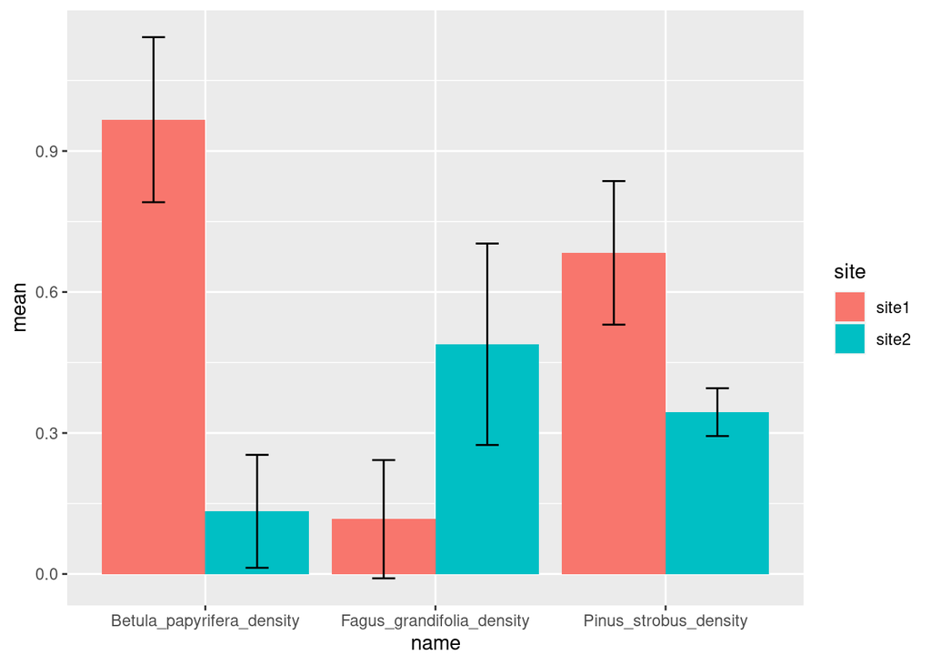

```r
final_plot <- ggplot(average_density,  aes(x = name, fill = site)) +
    geom_bar(stat="identity", aes(y = mean), position=position_dodge()) +
    # The line below creates error bars
    geom_errorbar(aes(ymin=mean-sd, ymax=mean+sd), width=.2,
                                position=position_dodge(.9))
final_plot
```

Finally, we’ll edit the plot to add a title and caption. To recieve extra credit, modify the code below to add a custom title and caption.

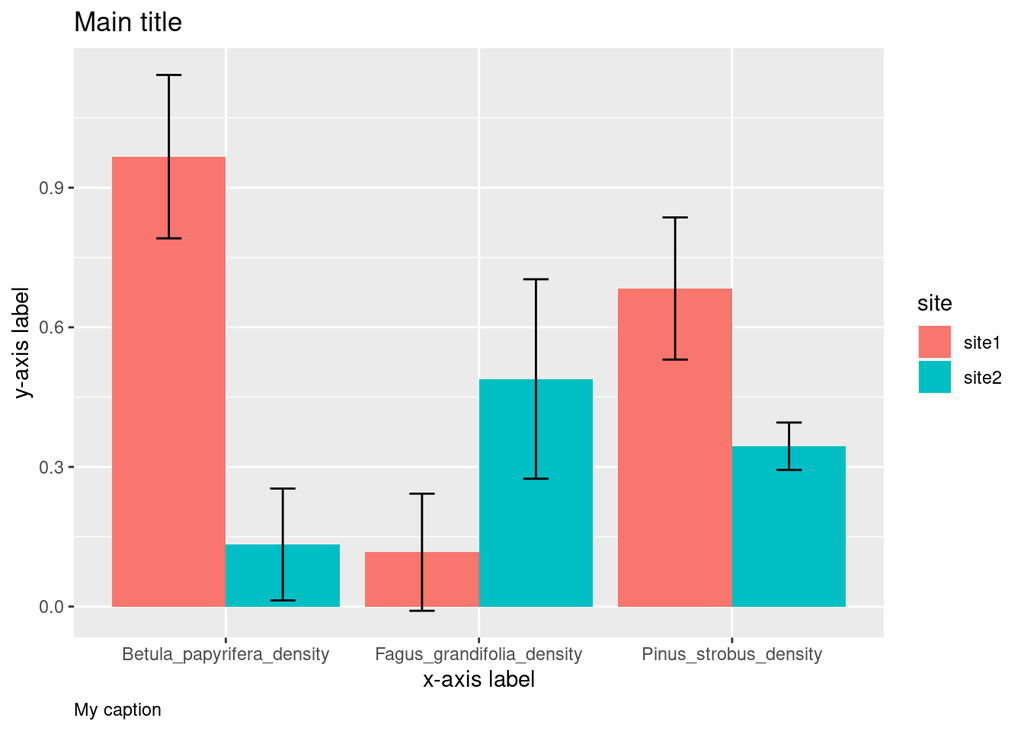

```r
final_plot + labs(title = "Main title", caption = "My caption") +
    xlab("x-axis label") +
    ylab("y-axis label") +
    theme(plot.caption = element_text(hjust = 0))
```